# NOAA Storm Database analysis_RR Course project 2

JB

2023-09-15

# Synopsis

In this project, our focus was on analyzing a comprehensive database obtained from the U.S. National Oceanic and Atmospheric Administration (NOAA). The goal of this analysis was to determine which weather events cause the most health and economic damages. Regarding the health impact, fatalities and injuries were combined into a total causlties metric. Based on that, it came out that tornados cause the biggest harm to the population of United States. Within the economic impact, combined crops and proparty damages showed that floods have the biggest economc consequence. # Data Processing The file was download and read as a csv file. For this analysis we will use the dplyr and ggplot2 packages.

```r
if(!file.exists("./data")){dir.create("./data")}
fileurl<- "https://d396qusza40orc.cloudfront.net/repdata%2Fdata%2FStormData.csv.bz2"
download.file(fileurl, destfile = "data/StormData.csv", method = "curl" )
# reading data
storm<- read.csv("data/StormData.csv")
library(dplyr)
library(ggplot2)
```

# Question 1

## Across the United States, which types of events (as indicated in the EVTYPE variable) are most harmful with respect to population health?

This analysis will be done in following steps:

1.Creating a new data frame with the necessery variables where the observations are grouped on the basis of the EVTYPE

```r
q1_group <- storm %>% select(FATALITIES, INJURIES, EVTYPE) %>%
                       group_by(EVTYPE) %>%
                       mutate(Casualties = FATALITIES + INJURIES)
```

2.Sum up the injuries and fatalities for each type of event and arrange in descending order

```r
q1_answer<-aggregate(cbind(FATALITIES, INJURIES, Casualties) ~ EVTYPE, data = q1_group, sum)
q1_answer <-q1_answer[order(q1_answer$Casualties, q1_answer$FATALITIES, q1_answer$INJURIES, decreasing = TRUE),]
```

3.Remove the previous data frames for clearance

```r
rm(q1_group)
```

# Question 2

##Across the United States, which types of events have the greatest economic consequences? In the storm data the damage estimates were entered as dollar amounts (PROPDMG) but the amount was rounded to three digits and the magnitude was signified by K for thousands, M for million and B for billion. For the analysis we need to change those to numerical vaules.

1. Create a new variable where letter are changed to coressponding numbers and then use it to multiply the numbers. This was done for both property and crops variables.

```r
q2<- storm %>% select(EVTYPE, PROPDMG, PROPDMGEXP, CROPDMG,CROPDMGEXP)
q2$PROPDMG_AMOUNT<- with(q2,
                            ifelse(PROPDMGEXP %in% c("k","K"), PROPDMG*1000,
                                   ifelse(PROPDMGEXP %in% c("m","M"), PROPDMG*1000000,
                                          ifelse(PROPDMGEXP %in% c("b","B"), PROPDMG*1000000000,
                                                 0)
                                          )
                            )
)

q2$CROPDMG_AMOUNT<- with(q2,
                         ifelse(CROPDMGEXP %in% c("k","K"), CROPDMG*1000,
                                ifelse(CROPDMGEXP %in% c("m","M"), CROPDMG*1000000,
                                       ifelse(CROPDMGEXP %in% c("b","B"), CROPDMG*1000000000,
                                              0)
                                )
                         )
)
```

2. The data fram was changes by adding and selecting a new variable that’s the sum of crops and property damages values per event type.

```r
q2<- q2 %>% mutate(TOTAL_DMG_VALUE = CROPDMG_AMOUNT+PROPDMG_AMOUNT) %>%
                   select(EVTYPE, TOTAL_DMG_VALUE)
```

3. The values for Total damages was calculated and arranged in descending order.

```r
q2_answer<- aggregate(TOTAL_DMG_VALUE~EVTYPE, data = q2, sum)
q2_answer<- arrange(q2_answer, desc(TOTAL_DMG_VALUE))
```

# Results

## Question 1

For the plot we need to create a data frame that combines the data related to “FATALITIES” and “INJURIES” categories. For that the 15 most damaging events were selected.

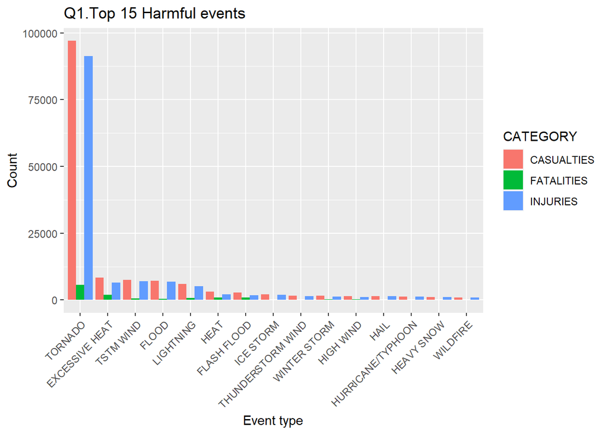

```r
q1_answer_plot<- q1_answer[1:15,]
q1_answer_plot <- rbind(
          cbind(select(q1_answer_plot, c(EVTYPE,"COUNT" = FATALITIES)),"CATEGORY" = "FATALITIES"),
          cbind(select(q1_answer_plot, c(EVTYPE,"COUNT" = INJURIES)),"CATEGORY" = "INJURIES"),
          cbind(select(q1_answer_plot, c(EVTYPE, "COUNT"= Casualties)), "CATEGORY" = "CASUALTIES")
)

q1_answer_plot %>%
          ggplot(aes(fill=CATEGORY, y=COUNT, x=reorder(EVTYPE,-COUNT)))+
          geom_bar(position = "dodge", stat = "identity")+
          labs(title = "Q1.Top 15 Harmful events", x="Event type", y = "Count")+
          theme(axis.text.x = element_text(angle = 45, hjust = 1))
```

## Question 2

Also first 15 most damaging events were selected.

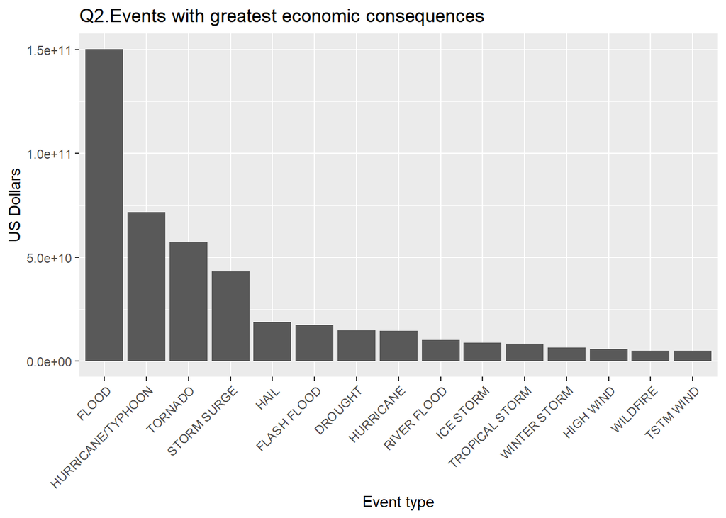

```r
q2_answer_plot<- q2_answer[1:15,]
q2_answer_plot %>%
          ggplot(aes(y=TOTAL_DMG_VALUE, x=reorder(EVTYPE,-TOTAL_DMG_VALUE)))+
          geom_bar(position = "dodge", stat = "identity")+
          labs(title = "Q2.Events with greatest economic consequences", x="Event type", y = "US Dollars")+
          theme(axis.text.x = element_text(angle = 45, hjust = 1)
                )
```